# Seminar 3

## Predicted/fitted values

Now, we want to plot out the interaction effect (see Brambor). We start by setting all variables to some constant, except for the variables we want to vary in the plot.

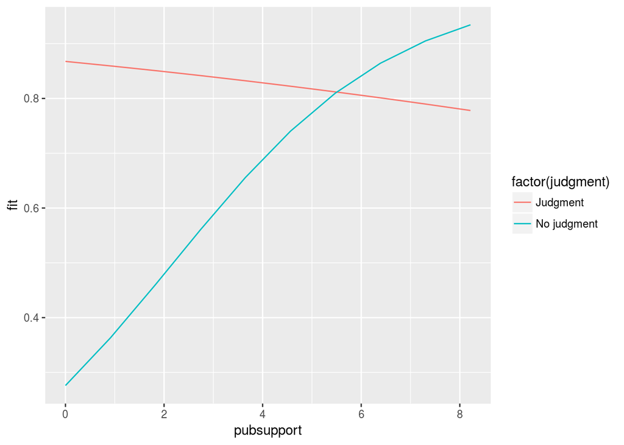

```r
test_set <- data.frame(judgment = c(rep(0, 10), rep(1, 10)), # setting the judgment to vary between 0 and 1
                        pubsupport = rep(seq(min(lgbt$pubsupport, na.rm=TRUE),
                                         max(lgbt$pubsupport, na.rm=TRUE),
                                         length.out = 10), 2), # Public support vary between min/max
                        ecthrcountry = 0, # setting the ecthr judgment against country to 0
                        lgbtlaws = mean(lgbt$lgbtlaws, na.rm = T), # Other LGBT rights set to mean
                        cond = 1, # Under CoE or EU conditionality scrutiny
                        eumember0 = 0, # not EU member
                        euemploy = 0, # not  EU employement directive in force
                        coemembe = 1, # CoE member
                        lngdp = mean(lgbt$lngdp, na.rm = T), # setting Natural log of gdp per capita to mean
                        issue = 5, # issue set to 5
                        year = 2003, # time trend to 2003
                        ccode = 640) # Turkey

# Binding the test set and predicted probabilities (with se)
test_set <- data.frame(test_set,
                        predict(logit, newdata = test_set, type = "response", se.fit = TRUE))

# Upper and lower confidence bands
test_set$upr <- test_set$fit + abs(qt(0.05/2, length(logit$fitted.values))) * test_set$se.fit
test_set$lwr <- test_set$fit - abs(qt(0.05/2, length(logit$fitted.values))) * test_set$se.fit
test_set$judgment <- ifelse(test_set$judgment == 1, "Judgment", "No judgment")

# Plotting
library(ggplot2)
interaction_plot1 <- ggplot(test_set, aes(x = pubsupport, y = fit, color = factor(judgment)))

interaction_plot1 + geom_line() # No confidence bands
```

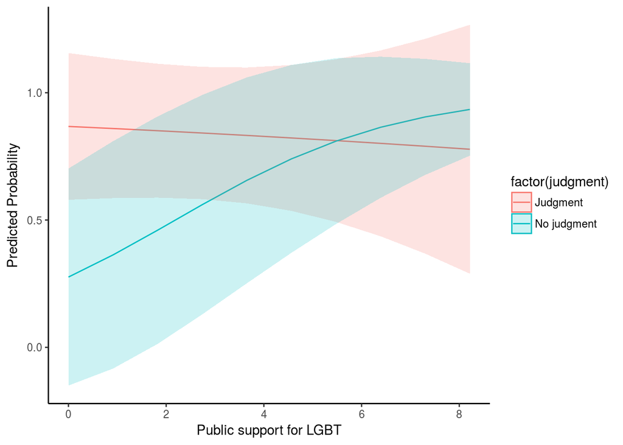

```r
interaction_plot1 <- ggplot(test_set, aes(x = pubsupport, y = fit, color = factor(judgment))) +
  geom_line() +
  geom_ribbon(aes(ymin = lwr, ymax = upr, fill = factor(judgment), color = NULL), alpha = .2)+
  labs(y = "Predicted Probability", x = "Public support for LGBT")+
  theme_classic()

interaction_plot1
```

## Simulation

With the simulation approach, we need to make different scenarios where we want to see the effect of pubsupport. The important thing is to have set values for all the needed parameters (including the intercept). Fixing the values can be done by creating a matrix with the values you want.

```r
library(MASS)
```

```r
simulated.betas <- mvrnorm(1000,  ## this is the number of draws. This number is just arbitrarely picked. You can set any large number here.
                           mu = coefficients(logit), ## this is the coefficients from the model
                           Sigma = vcov(logit)) ## this is the variance covariance matrix from the model

range.x <- seq(min(lgbt$pubsupport, na.rm=TRUE),  ### I want the sequence to start at the minimum value
               max(lgbt$pubsupport, na.rm=TRUE), ### I want it to end at the maximum value
               length.out = 10) ## I want ten different values on that range

set.x1 <- cbind(1, # intercept
                1,  # setting the judgment to 1
                range.x, # setting a range to the public support variable
                range.x * 1, ## the interaction term. Since the judgment is 1 and the interaction is between the pubsupport variable and judgment
                   ## the interaction term must be range.x * 1 == range.x
                0, ## setting the ecthr judgment against country to 0
                mean(lgbt$lgbtlaws, na.rm = T), # Other LGBT rights set to mean
                1 ,      # Under CoE or EU conditionality scrutiny
                0  , # not EU member
                0 ,  #not  EU employement directive in force
                1 , # CoE member
                mean(lgbt$lngdp, na.rm = T),     # setting Natural log of gdp per capita to mean
                2003 ,      # time trend to 2003
                0, # 0 for issue are 1
                0, # 0 for issue are 2
                0, # 0 for issue are 3
                0, # 0 for issue are 4
                1,  # issue area 5,
                0 , 0 , 0 , 0, 0, 0, 0, 0 ,0 ,0 ,0, 0 ,0 ,0 ,0 ,0 ,0 ,0 ,0 ,0 ,0 ,0 ,0 ,0 ,0 ,0, 0, 0, 0, 0, 0, 0, 0, 0, 0, 0, 0, 0, 0,  # 0 for all the first 41 country dummies
                1)  # 1 for Turkey

length(unique(lgbt$ccode))
```

```
## [1] 42
```

```r
### Check if this is true. If it is not true, you will have problems with the matrix multiplication.
ncol(simulated.betas) == ncol(set.x1)
```

```
## [1] TRUE
```

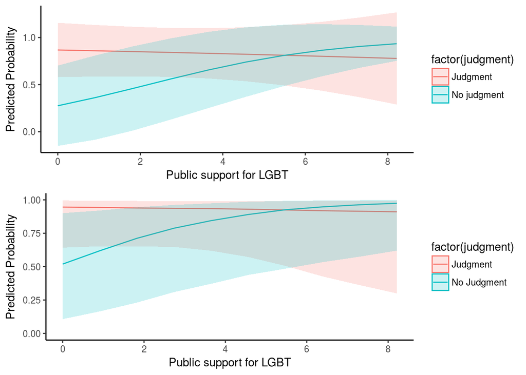

```r
##### if we wanted the effect without a ruling we would need to set x variables  differently:

set.x0 <- cbind(1, # intercept
                0,  # setting the judgment to 1
                range.x, # setting a range to the public support variable
                range.x * 0, ## the interaction term  Since the judgment variable is 0. the interaction term will be range.x *0 ==  0
                0, ## setting the ecthr judgment against country to 0
                mean(lgbt$lgbtlaws, na.rm = T), # Other LGBT rights set to mean
                1 ,      # Under CoE or EU conditionality scrutiny
                0  , # not EU member
                0 ,  #not  EU employement directive in force
                1 , # CoE member
                mean(lgbt$lngdp, na.rm = T),     # setting Natural log og gdp per capita to mean
                2003 ,      # line
                0, # 0 for issue are 1
                0, # 0 for issue are 2
                0, # 0 for issue are 3
                0, # 0 for issue are 4
                1,  # issue area 5,
                0 , 0 , 0 , 0, 0, 0, 0, 0 ,0 ,0 ,0, 0 ,0 ,0 ,0 ,0 ,0 ,0 ,0 ,0 ,0 ,0 ,0 ,0 ,0 ,0, 0, 0, 0, 0, 0, 0, 0, 0, 0, 0, 0, 0, 0,  # 0 for all the first 41 country dummies
                1)  # 1 for Turkey

### calculating our quantity of interest

## Now, we multiply the values in the scenario with all the 1000 draws

## for the case with a judgment
x.beta1 <- set.x1 %*% t(simulated.betas ) # Multiplying the matrices.
exp.y1 <- 1/(1+exp(-x.beta1)) #This is the predicted probability

## for the case without a judgment

x.beta0 <- set.x0 %*% t(simulated.betas ) # Multiplying the matrices.
exp.y0 <- 1/(1+exp(-x.beta0))  #This is the predicted probability


### Preparing the plot in the same way as last week

## for the case with a judgment:
quantile.values1 <- apply(X = exp.y1,  ##apply(exp.y1,MARgin = 1 ...) means that I want to do something with all the rows of exp.y1.
                          MARGIN = 1,
                          FUN =  ## The fun argument defines what I want to do with all the rows
                            ## What we want to do here is to use quantile to get the quantiles representing the lower and upper
                            ### bounds of the confidence intervals and our point estimates:
                            quantile, probs = c(.05,.5,.95))  ## changed to 90 per cent confidence interval

##The quantile.values1 matrix should contain the lower and upper bounds of the confidence intervals and
## the point estimate for each combination of fixed values and the values on the variable we have the range for.


### This part of the code just binds together range.x and the quantile.values 1 matrix so we have a matrix of x values and corresponding y values
### that we can plot. We take t(quantile.values1) simply to get the dimensions to match.

plot.points1 <- cbind(range.x,
                      t(quantile.values1))


## for the case without a judgment:
quantile.values0 <- apply(X = exp.y0, MARGIN = 1, FUN = quantile, probs = c(.05,.5,.95)) ## changed to 90 per cent confidence interval
plot.points0 <- cbind(range.x, t(quantile.values0))
## Creating the plot

### Some of you have asked how to make the same plot in ggplot2. Here is one example:


plot.points <- as.data.frame(rbind(cbind(plot.points1, "Judgment"),
                                   cbind(plot.points0, "No Judgment")),
                             stringsAsFactors = FALSE)



colnames(plot.points) <- c("range.x", "lower", "mid", "upper", "judgment")

library(ggplot2)
interaction_plot2 <- ggplot(plot.points, aes(x=as.numeric(range.x), y=as.numeric(mid),
                                             color = factor(judgment), fill = factor(judgment)))+
  geom_line()+
  geom_ribbon(aes(ymin = as.numeric(lower) , ymax = as.numeric(upper), color = NULL), alpha=0.2) +
  labs(y = "Predicted Probability", x = "Public support for LGBT")+
  ylim(0,1) +
  theme_classic()

library(gridExtra)
grid.arrange(interaction_plot1, interaction_plot2)
```

## Separation plot

How well does our predicted probabilities help us separate 0s and 1s? (See http://www.csss.washington.edu/Anniversary/Poster/BrianGreenhill.pdf)

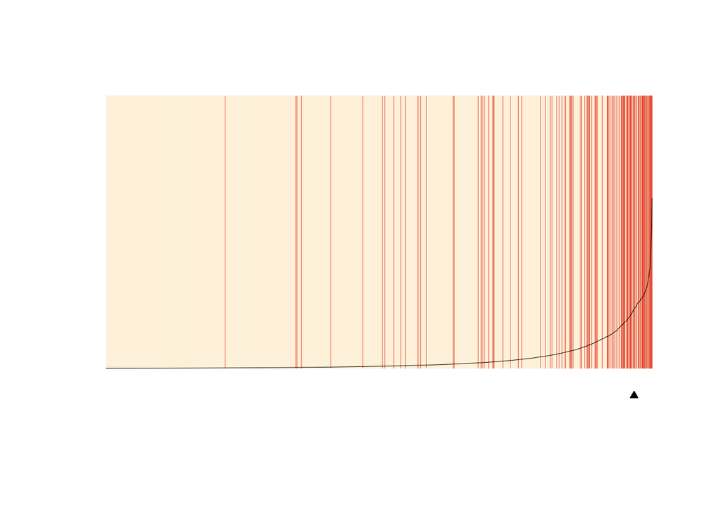

```r
library(separationplot)

separationplot(pred = logit$fitted.values, actual = as.numeric(logit$y), show.expected = TRUE, newplot = FALSE)
```

# Multinomial logit model

In multinomial logit models we have more than two different outcomes. A typical example is voting. A (perhaps) atypical example of voting data is Braaten’s (2014) study of whether US voting in multilateral banks is affected by human rights and other foreign policy considerations (you can read the JPR article here: http://jpr.sagepub.com/content/early/2014/05/06/0022343314524219.abstract)

```r
## Because the US can choose between yes, no and abstaining,
## a multinomial model is appropriate

##### Braaten's data in a Stata 13 file:
us_forpol <- read_dta("./data/HRandUSFPinMDBdata.dta")

head(us_forpol)  ## the unit of analysis is votes in multilateral development banks on where the US has
```

```
## # A tibble: 6 x 26
##       country  year cowcode countryyear  bank window   votes USVOTE codes   pts    PI  fhpr   POL
##         <chr> <dbl>   <dbl>       <dbl> <chr>  <chr>   <chr>  <dbl> <chr> <dbl> <dbl> <dbl> <dbl>
## 1 Afghanistan  2004     700     7002004   ADB    ADB Support      2           4     2     6     2
## 2 Afghanistan  2004     700     7002004   ADB    ADF Support      2           4     2     6     2
## 3 Afghanistan  2004     700     7002004   ADB    ADF Support      2           4     2     6     2
## 4 Afghanistan  2004     700     7002004    WB    IDA Support      2           4     2     6     2
## 5 Afghanistan  2004     700     7002004    WB   MIGA Support      2           4     2     6     2
## 6 Afghanistan  2004     700     7002004    WB   MIGA Support      2           4     2     6     2
## # ... with 13 more variables: EMPIX <dbl>, DEMOCRACY <dbl>, UNVOTE <dbl>, DEV <dbl>, TRADE <dbl>,
## #   militaryaid <dbl>, MILAID <dbl>, CONFLICT <dbl>, IDEOLOGY <dbl>, POPULATION <dbl>,
## #   lnTRADE <dbl>, lnDEV <dbl>, lnPOPULATION <dbl>
```

```r
## participated. Because countries differ in their propensity to ask for development
## aid, the data will be highly unbalanced

nrow(us_forpol)  #13107 votes
```

```
## [1] 13107
```

```r
range(us_forpol$year)  ## time span from 2004 till 2011
```

```
## [1] 2004 2011
```

```r
length(unique(us_forpol$country)) ## 181 countries have asked for aid/loans
```

```
## [1] 181
```

```r
#### The dependent variable is how the US voted in each vote:

## We will recode it so it makes more sense:
us_forpol$USVOTE <-factor(ifelse(us_forpol$USVOTE == 2, "Yes",
                              ifelse(us_forpol$USVOTE == 0, "No",
                                     ifelse(us_forpol$USVOTE==1, "Abstain",NA))))


us_forpol$USVOTE <- relevel(us_forpol$USVOTE, ref = "Yes") ## Telling R, we want "yes" to be the reference category

### We will just replicate the first model of Table 1:

library(nnet)
multinom <- multinom(USVOTE ~ ## our dependen variable
                       POL +  # Political rights in recipient country
                       PI  +  # Phycical integrity rights in recipient country
                       MILAID  + # Military aid to recipient country
                       UNVOTE  + # Un voting similarity
                       lnTRADE +  # Level of trade
                       lnDEV  +  # Level of development
                       IDEOLOGY + # Ideology
                       CONFLICT + # Conflict
                       lnPOPULATION,
                     data = us_forpol,
                     Hess = TRUE)
summary(multinom)
```

```
## Call:
## multinom(formula = USVOTE ~ POL + PI + MILAID + UNVOTE + lnTRADE +
##     lnDEV + IDEOLOGY + CONFLICT + lnPOPULATION, data = us_forpol,
##     Hess = TRUE)
##
## Coefficients:
##         (Intercept)         POL          PI     MILAID     UNVOTE      lnTRADE      lnDEV  IDEOLOGY
## Abstain   -4.411714 -0.20217732  0.06197883 -0.6556584 -0.6163743 -0.004658095 0.07226892 0.4195162
## No       -12.103654 -0.08444219 -0.41053601 -1.2519950  1.7045793 -0.587868482 0.92109202 0.8689925
##           CONFLICT lnPOPULATION
## Abstain -0.4636064    0.1646599
## No      -0.2168692    0.4522809
##
## Std. Errors:
##         (Intercept)        POL         PI     MILAID    UNVOTE    lnTRADE      lnDEV   IDEOLOGY
## Abstain   0.8007114 0.02624047 0.06281572 0.08496947 0.2591092 0.03099021 0.04835071 0.08931471
## No        1.2644567 0.03953413 0.08814716 0.11875818 0.3722686 0.04981356 0.07785306 0.12608286
##          CONFLICT lnPOPULATION
## Abstain 0.1027407   0.04231394
## No      0.1622398   0.06857233
##
## Residual Deviance: 9959.183
## AIC: 9999.183
```

```r
head(multinom$fitted.values)
```

```
##         Yes    Abstain         No
## 1 0.8894232 0.07935307 0.03122373
## 2 0.8894232 0.07935307 0.03122373
## 3 0.8894232 0.07935307 0.03122373
## 4 0.8894232 0.07935307 0.03122373
## 5 0.8894232 0.07935307 0.03122373
## 6 0.8894232 0.07935307 0.03122373
```

```r
###How to report in stargazer:
stargazer(multinom, type="html")
```

|  | *Dependent variable:* |  |
| --- | --- | --- |
|  | Abstain | No |
|  | (1) | (2) |
| POL | -0.202*** | -0.084** |
|  | (0.026) | (0.040) |
| PI | 0.062 | -0.411*** |
|  | (0.063) | (0.088) |
| MILAID | -0.656*** | -1.252*** |
|  | (0.085) | (0.119) |
| UNVOTE | -0.616** | 1.705*** |
|  | (0.259) | (0.372) |
| lnTRADE | -0.005 | -0.588*** |
|  | (0.031) | (0.050) |
| lnDEV | 0.072 | 0.921*** |
|  | (0.048) | (0.078) |
| IDEOLOGY | 0.420*** | 0.869*** |
|  | (0.089) | (0.126) |
| CONFLICT | -0.464*** | -0.217 |
|  | (0.103) | (0.162) |
| lnPOPULATION | 0.165*** | 0.452*** |
|  | (0.042) | (0.069) |
| Constant | -4.412*** | -12.104*** |
|  | (0.801) | (1.264) |
| Akaike Inf. Crit. | 9,999.183 | 9,999.183 |
| *Note:* | p<0.1; p<0.05; p<0.01 |  |

# The ordered logit model

The final type of model discussed this week is the ordered logit model, which is appropriate for dependent variables on the ordinal level. Categories are ranked, but the variable is not on metric scale. We would like to take the ordering into account, but an OLS may be inappropriate. The example may be levels of repression in a state. We may be able to measure repression levels even if cannot measure repression on a continous scale. Thus, Wright(2014) uses ordinal logistic regression to measure how territorial conflicts affect levels of state repression: (link to article: http://jpr.sagepub.com/content/51/3/375.full.pdf)

### Replication data from Wright:

```r
wright <-read_dta("./data/Wright2014JPR_replication.dta")

head(wright) # panel data with country-years
```

```
## # A tibble: 6 x 85
##   stateabb ccode  year       country amnesty statedept ainew sdnew polity2    pop    gdppc
##      <chr> <dbl> <dbl>         <chr>   <dbl>     <dbl> <dbl> <dbl>   <dbl>  <dbl>    <dbl>
## 1      USA     2  1976 United States       1        NA     1     1      10 218086  8277.93
## 2      USA     2  1977 United States       1        NA     1     1      10 220289  9132.09
## 3      USA     2  1978 United States       1        NA     1     1      10 222629 10218.79
## 4      USA     2  1979 United States       1        NA     1     1      10 225106 11303.56
## 5      USA     2  1980 United States       1        NA     1     1      10 227726 12170.33
## 6      USA     2  1981 United States       1        NA     1     1      10 230008 13497.36
## # ... with 74 more variables: civconflict <dbl>, terrrev <dbl>, terrsq <dbl>, fatality <dbl>,
## #   anymid <dbl>, nonfatal <dbl>, lpop_lag <dbl>, lgdppc_lag <dbl>, dem <dbl>, dem_lag <dbl>,
## #   dem7 <dbl>, dem7_lag <dbl>, terrXfatality <dbl>, demXterr <dbl>, demXfatality <dbl>,
## #   demXterrXfatality <dbl>, terrsqXfatality <dbl>, demXterrsq <dbl>, demXterrsqXfatality <dbl>,
## #   ai_lag <dbl>, ai1 <dbl>, ai2 <dbl>, ai3 <dbl>, ai4 <dbl>, ai5 <dbl>, sd_lag <dbl>, sd1 <dbl>,
## #   sd2 <dbl>, sd3 <dbl>, sd4 <dbl>, sd5 <dbl>, cdem <dbl>, cdem_lag <dbl>, cdemXterr <dbl>,
## #   cdemXfatality <dbl>, cdemXterrXfatality <dbl>, transborder <dbl>, demXtrans <dbl>,
## #   terrXtrans <dbl>, demXtransXterr <dbl>, terrXtransXfatal <dbl>, transXfatal <dbl>,
## #   physint <dbl>, ciri <dbl>, ciri_lag <dbl>, ciri0 <dbl>, ciri1 <dbl>, ciri2 <dbl>, ciri3 <dbl>,
## #   ciri4 <dbl>, ciri5 <dbl>, ciri6 <dbl>, ciri7 <dbl>, ciri8 <dbl>, rev <dbl>, revXfatality <dbl>,
## #   ntrev <dbl>, ntrevXfatal <dbl>, ptsincrease <dbl>, ptsdecrease <dbl>, m_terrrev <dbl>,
## #   m_fatality <dbl>, m_nonfatal <dbl>, m_terrXfatality <dbl>, m_demXterr <dbl>,
## #   m_demXfatality <dbl>, m_demXterrXfatality <dbl>, e_terrrev <dbl>, e_fatality <dbl>,
## #   e_nonfatal <dbl>, e_terrXfatality <dbl>, e_demXterr <dbl>, e_demXfatality <dbl>,
## #   e_demXterrXfatality <dbl>
```

```r
range(wright$year) # time-span: 1976-2001
```

```
## [1] 1976 2001
```

```r
length(unique(wright$ccode))  # 201 countries
```

```
## [1] 201
```

The dependent variable is a scale of repression on physical integrity rights based on Amnesty International reports ranging from least repressive (1) to most repressive (5):

```r
table(wright$ainew)
```

```
##
##    1    2    3    4    5
## 1046 1202 1097  582  248
```

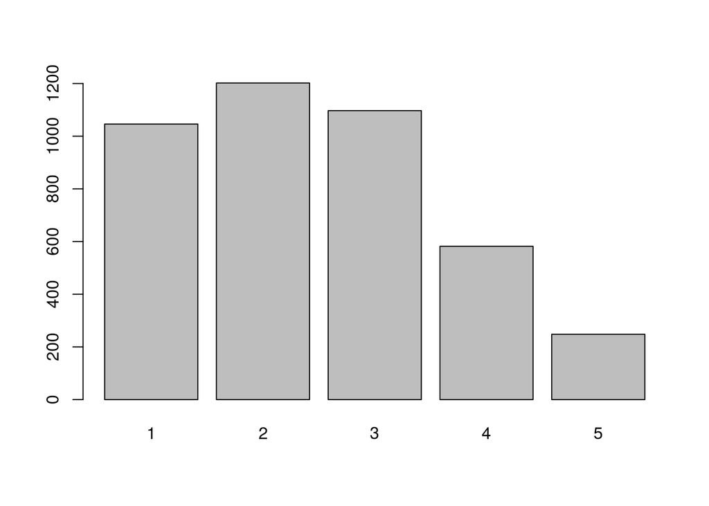

```r
barplot(table(wright$ainew))
```

```r
### We will replicate model 1 in the Table 1:

library(ordinal)
### Using clm from the ordinal package
ologit <- clm(factor(ainew) ~
               ai1 + ai2 + ai3 + ai4 +  ## set of binary lags of the categories on the dependent variable
               terrrev + ### territorial revisionist
               fatality + ### Militarized interstate dispute fatalities
               lpop_lag + ### lagged log(population)
               lgdppc_lag + ### lagged log(gdp per capita)
               civconflict + ## civil conflict
               nonfatal + ### Non-fatal Militarized interstate dispute
               dem_lag, ## lagged democracy
             data = wright,
             link = "logit")

names(ologit)
```

```
##  [1] "aliased"       "alpha"         "beta"          "call"          "coefficients"  "cond.H"
##  [7] "control"       "convergence"   "df.residual"   "edf"           "fitted.values" "formula"
## [13] "formulas"      "gradient"      "Hessian"       "info"          "link"          "logLik"
## [19] "maxGradient"   "message"       "model"         "n"             "na.action"     "niter"
## [25] "nobs"          "start"         "terms"         "Theta"         "threshold"     "tJac"
## [31] "vcov"          "xlevels"       "y"             "y.levels"
```

```r
coefficients(ologit)
```

```
##         1|2         2|3         3|4         4|5         ai1         ai2         ai3         ai4
## -8.68841364 -5.34305586 -2.28400784  0.43939683 -8.83721679 -6.00231021 -3.95385880 -1.96338889
##     terrrev    fatality    lpop_lag  lgdppc_lag civconflict    nonfatal     dem_lag
##  0.28523617  0.01316401  0.13779586 -0.21089928  1.43279295  0.13378758 -0.61578076
```

```r
# Thresholds:
ologit$Theta
```

```
##            1|2       2|3       3|4       4|5
## [1,] -8.688414 -5.343056 -2.284008 0.4393968
```

```r
### Alternative: Using polr from the MASS package
ologit2 <- polr(factor(ainew) ~
                  ai1 + ai2 + ai3 + ai4 +  ## set of binary lags of the categories on the dependent variable
                  terrrev + ### territorial revisionist
                  fatality + ### Militarized interstate dispute fatalities
                  lpop_lag + ### lagged log(population)
                  lgdppc_lag + ### lagged log(gdp per capita)
                  civconflict + ## civil conflict
                  nonfatal + ### Non-fatal Militarized interstate dispute
                  dem_lag, ## lagged democracy
                data = wright,
                Hess = T,
                method = "logistic")
```

```r
stargazer(ologit, ologit2, type = "html")
```

|  | *Dependent variable:* |  |
| --- | --- | --- |
|  | ainew |  |
|  | *cumulative* | *ordered* |
|  | *link* | *logistic* |
|  | (1) | (2) |
| ai1 | -8.837*** | -8.837*** |
|  | (0.238) | (0.238) |
| ai2 | -6.002*** | -6.002*** |
|  | (0.208) | (0.208) |
| ai3 | -3.954*** | -3.954*** |
|  | (0.192) | (0.192) |
| ai4 | -1.963*** | -1.963*** |
|  | (0.177) | (0.177) |
| terrrev | 0.285** | 0.285** |
|  | (0.141) | (0.142) |
| fatality | 0.013 | 0.013 |
|  | (0.041) | (0.041) |
| lpop_lag | 0.138*** | 0.138*** |
|  | (0.025) | (0.025) |
| lgdppc_lag | -0.211*** | -0.211*** |
|  | (0.039) | (0.039) |
| civconflict | 1.433*** | 1.433*** |
|  | (0.107) | (0.107) |
| nonfatal | 0.134 | 0.134 |
|  | (0.084) | (0.084) |
| dem_lag | -0.616*** | -0.616*** |
|  | (0.090) | (0.090) |
| Observations | 3,538 | 3,538 |
| Log Likelihood | -3,065.465 |  |
| *Note:* | p<0.1; p<0.05; p<0.01 |  |